# Magic: The Gathering Cards

```r
library(fmsb)
library(ggplot2)
library(dplyr, warn.conflicts = FALSE)

cartas <- read.csv2("../datasets-csv/cards.csv", sep=",", encoding="utf-8")
head(cartas)
```

|  | artist | artistIds | asciiName | attractionLights | availability | boosterTypes | borderColor | cardParts | colorIdentity | colorIndicator | colors | defense | duelDeck | edhrecRank | edhrecSaltiness | faceConvertedManaCost | faceFlavorName | faceManaValue | faceName | finishes | flavorName | flavorText | frameEffects | frameVersion | hand | hasAlternativeDeckLimit | hasContentWarning | hasFoil | hasNonFoil | … |
| --- | --- | --- | --- | --- | --- | --- | --- | --- | --- | --- | --- | --- | --- | --- | --- | --- | --- | --- | --- | --- | --- | --- | --- | --- | --- | --- | --- | --- | --- | --- |
| 1 | Pete Venters | d54c4a1a-c0c5-4834-84db-125d341f3ad8 |  |  | mtgo, paper | default | black |  | W |  | W | NA |  | 21077.0 | 0.14 |  |  |  |  | nonfoil |  |  |  | 2003 | NA |  |  | False | True | … |
| 2 | Pete Venters | d54c4a1a-c0c5-4834-84db-125d341f3ad8 |  |  | mtgo, paper | default | black |  | W |  | W | NA |  | 21077.0 | 0.14 |  |  |  |  | foil |  | "The will of all, by my hand done." |  | 2003 | NA |  |  | True | False | … |
| 3 | Volkan Baǵa | 93bec3c0-0260-4d31-8064-5d01efb4153f |  |  | mtgo, paper | default | black |  | W |  | W | NA |  | 17087.0 | 0.36 |  |  |  |  | nonfoil |  | Every tear shed is a drop of immortality. |  | 2003 | NA |  |  | False | True | … |
| 4 | Volkan Baǵa | 93bec3c0-0260-4d31-8064-5d01efb4153f |  |  | mtgo, paper | default | black |  | W |  | W | NA |  | 17087.0 | 0.36 |  |  |  |  | foil |  | Every tear shed is a drop of immortality. |  | 2003 | NA |  |  | True | False | … |
| 5 | Mark Zug | 48e2b98c-5467-4671-bd42-4c3746115117 |  |  | mtgo, paper | default | black |  | W |  | W | NA |  | 22901.0 | 0.05 |  |  |  |  | nonfoil |  | Only the warrior who can admit mortal weakness will be bolstered by immortal strength. |  | 2003 | NA |  |  | False | True | … |
| 6 | Mark Zug | 48e2b98c-5467-4671-bd42-4c3746115117 |  |  | mtgo, paper | default | black |  | W |  | W | NA |  | 22901.0 | 0.05 |  |  |  |  | foil |  | Only the warrior who can admit mortal weakness will be bolstered by immortal strength. |  | 2003 | NA |  |  | True | False | … |

```r
summary(cartas)
```

```
    artist           artistIds          asciiName         attractionLights   availability
 Length:91968       Length:91968       Length:91968       Length:91968       Length:91968
 Class :character   Class :character   Class :character   Class :character   Class :character
 Mode  :character   Mode  :character   Mode  :character   Mode  :character   Mode  :character




 boosterTypes       borderColor         cardParts         colorIdentity      colorIndicator
 Length:91968       Length:91968       Length:91968       Length:91968       Length:91968
 Class :character   Class :character   Class :character   Class :character   Class :character
 Mode  :character   Mode  :character   Mode  :character   Mode  :character   Mode  :character




    colors             defense        duelDeck          edhrecRank        edhrecSaltiness
 Length:91968       Min.   :3.00    Length:91968       Length:91968       Length:91968
 Class :character   1st Qu.:4.00    Class :character   Class :character   Class :character
 Mode  :character   Median :4.00    Mode  :character   Mode  :character   Mode  :character
                    Mean   :4.63
                    3rd Qu.:5.00
                    Max.   :7.00
                    NA's   :91916
 faceConvertedManaCost faceFlavorName     faceManaValue        faceName           finishes
 Length:91968          Length:91968       Length:91968       Length:91968       Length:91968
 Class :character      Class :character   Class :character   Class :character   Class :character
 Mode  :character      Mode  :character   Mode  :character   Mode  :character   Mode  :character




  flavorName         flavorText        frameEffects       frameVersion            hand
 Length:91968       Length:91968       Length:91968       Length:91968       Min.   :-4.00
 Class :character   Class :character   Class :character   Class :character   1st Qu.:-1.00
 Mode  :character   Mode  :character   Mode  :character   Mode  :character   Median : 0.00
                                                                             Mean   : 0.08
                                                                             3rd Qu.: 1.00
                                                                             Max.   : 3.00
                                                                             NA's   :91849
```

[output cut: 69 more lines]

```



     text            toughness             type              types               uuid
 Length:91968       Length:91968       Length:91968       Length:91968       Length:91968
 Class :character   Class :character   Class :character   Class :character   Class :character
 Mode  :character   Mode  :character   Mode  :character   Mode  :character   Mode  :character




  variations         watermark
 Length:91968       Length:91968
 Class :character   Class :character
 Mode  :character   Mode  :character
```

```r
str(cartas)
```

```
'data.frame':   91968 obs. of  78 variables:
 $ artist                 : chr  "Pete Venters" "Pete Venters" "Volkan Baǵa" "Volkan Baǵa" ...
 $ artistIds              : chr  "d54c4a1a-c0c5-4834-84db-125d341f3ad8" "d54c4a1a-c0c5-4834-84db-125d341f3ad8" "93bec3c0-0260-4d31-8064-5d01efb4153f" "93bec3c0-0260-4d31-8064-5d01efb4153f" ...
 $ asciiName              : chr  "" "" "" "" ...
 $ attractionLights       : chr  "" "" "" "" ...
 $ availability           : chr  "mtgo, paper" "mtgo, paper" "mtgo, paper" "mtgo, paper" ...
 $ boosterTypes           : chr  "default" "default" "default" "default" ...
 $ borderColor            : chr  "black" "black" "black" "black" ...
 $ cardParts              : chr  "" "" "" "" ...
 $ colorIdentity          : chr  "W" "W" "W" "W" ...
 $ colorIndicator         : chr  "" "" "" "" ...
 $ colors                 : chr  "W" "W" "W" "W" ...
 $ defense                : int  NA NA NA NA NA NA NA NA NA NA ...
 $ duelDeck               : chr  "" "" "" "" ...
 $ edhrecRank             : chr  "21077.0" "21077.0" "17087.0" "17087.0" ...
```

[output cut: 64 more lines]

```r
ncol(cartas)
```

```
[1] 78
```

```r
nrow(cartas)
```

```
[1] 91968
```

# Mapeando colunas que serão observadas e adequando o dataset para observação

Além disso, em colunas que tem valores TRUE e outros com uma string vazia, transforma o vazio em FALSE, para que o atributo seja binário, como previsto.

```r
cartas <- cartas[, c("name", "colorIdentity", "colors", "power", "toughness", "defense", "manaCost", "manaValue", "life", "type", "rarity", "subtypes","isAlternative", "isPromo", "isRebalanced", "isReprint", "variations")]
str(cartas)

cartas$isAlternative <- ifelse(cartas$isAlternative == "", FALSE, TRUE)
cartas$isPromo <- ifelse(cartas$isPromo == "", FALSE, TRUE)
cartas$isRebalanced <- ifelse(cartas$isRebalanced == "", FALSE, TRUE)
cartas$isReprint <- ifelse(cartas$isReprint == "", FALSE, TRUE)
cartas_duplicadas <- duplicated(cartas[, 1:10]) | duplicated(cartas[, 1:10], fromLast = TRUE)
primeiras_ocorrencias <- !duplicated(cartas$name)
cartas_unicas <- cartas[!(cartas_duplicadas & !primeiras_ocorrencias), ]
cartas_unicas$manaValue <- as.numeric(cartas_unicas$manaValue)

cartas <- mutate(cartas, rarity = case_match(rarity, "mythic" ~ 4, "rare" ~3, "uncommon" ~ 2, "common" ~ 1, .default = 0))

nrow(cartas_unicas)
head(cartas_unicas)
```

[output not shown]

# Tratando valores nulos

Utilizaremos apenas as cartas que tem um número absoluto no valor de ataque e defesa. Se for nulo, deve ser desconsiderado, assim como quando contiver caracteres não numéricos.

```r
cartas_unicas$power <- as.numeric(cartas_unicas$power)
cartas_unicas <- subset(cartas_unicas, cartas_unicas$power >= 0 & !is.na(cartas_unicas$power) & cartas_unicas$power %% 1 == 0)
cartas_unicas$power <- as.integer(cartas_unicas$power)

cartas_unicas$toughness <- as.numeric(cartas_unicas$toughness)
cartas_unicas <- subset(cartas_unicas, cartas_unicas$toughness >= 0 & !is.na(cartas_unicas$toughness) & cartas_unicas$toughness %% 1 == 0)
cartas_unicas$toughness <- as.integer(cartas_unicas$toughness)
```

```r
categorizar_carta <- function(cor) {
  if (is.na(cor) || cor == "") {
    return("Sem Cor")
  } else if (grepl(",", cor)) {
    return("Multicolor")
  } else {
    color_map <- list(
      W = "Branca",
      U = "Azul",
      B = "Preta",
      R = "Vermelha",
      G = "Verde"
    )
    return(color_map[[cor]])
  }
}

cartas_unicas$colors <- sapply(cartas_unicas$colors, categorizar_carta)
print(cartas_unicas)
```

|  | name | colorIdentity | colors | power | toughness | defense | manaCost | manaValue | life | type | rarity | subtypes | isAlternative | isPromo | isRebalanced | isReprint | variations |
| --- | --- | --- | --- | --- | --- | --- | --- | --- | --- | --- | --- | --- | --- | --- | --- | --- | --- |
| 1 | Ancestor's Chosen | W | Branca | 4 | 4 | NA | {5}{W}{W} | 7 | NA | Creature — Human Cleric | uncommon | Human, Cleric | FALSE | FALSE | FALSE | TRUE | b7c19924-b4bf-56fc-aa73-f586e940bd42 |
| 3 | Angel of Mercy | W | Branca | 3 | 3 | NA | {4}{W} | 5 | NA | Creature — Angel | uncommon | Angel | FALSE | FALSE | FALSE | TRUE | 8fd4e2eb-3eb4-50ea-856b-ef638fa47f8a |
| 8 | Angelic Wall | W | Branca | 0 | 4 | NA | {1}{W} | 2 | NA | Creature — Wall | common | Wall | FALSE | FALSE | FALSE | TRUE | 60b93108-8790-591b-844e-c3d311698767 |
| 11 | Aven Cloudchaser | W | Branca | 2 | 2 | NA | {3}{W} | 4 | NA | Creature — Bird Soldier | common | Bird, Soldier | FALSE | FALSE | FALSE | TRUE | 6adaf14d-43e3-521a-adf1-960c808e5b1a |
| 13 | Ballista Squad | W | Branca | 2 | 2 | NA | {3}{W} | 4 | NA | Creature — Human Rebel | uncommon | Human, Rebel | FALSE | FALSE | FALSE | TRUE |  |
| 16 | Benalish Knight | W | Branca | 2 | 2 | NA | {2}{W} | 3 | NA | Creature — Human Knight | common | Human, Knight | FALSE | FALSE | FALSE | TRUE | 0d2a4e1d-cc12-5675-8044-9a7bc7d60050 |
| 18 | Cho-Manno, Revolutionary | W | Branca | 2 | 2 | NA | {2}{W}{W} | 4 | NA | Legendary Creature — Human Rebel | rare | Human, Rebel | FALSE | FALSE | FALSE | TRUE |  |
| 21 | Field Marshal | W | Branca | 2 | 2 | NA | {1}{W}{W} | 3 | NA | Creature — Human Soldier | rare | Human, Soldier | FALSE | FALSE | FALSE | TRUE | 6d6a31d5-a80b-5f31-9b46-2c2083a95581 |
| 23 | Ghost Warden | W | Branca | 1 | 1 | NA | {1}{W} | 2 | NA | Creature — Spirit | common | Spirit | FALSE | FALSE | FALSE | TRUE |  |
| 32 | Honor Guard | W | Branca | 1 | 1 | NA | {W} | 1 | NA | Creature — Human Soldier | common | Human, Soldier | FALSE | FALSE | FALSE | TRUE |  |

[output cut: 990 more lines]

# Separando as cartas pela cor

Aqui, separaremos as cartas em grupos:

-Sem cor -Brancas -Pretas -Azuis -Vermelhas -Verdes -Multicolores

```r
cartas_sem_cor <- subset(cartas_unicas, cartas_unicas$colors == "Sem Cor")
nrow(cartas_sem_cor)
```

```
[1] 939
```

```r
print(cartas_sem_cor)
```

|  | name | colorIdentity | colors | power | toughness | defense | manaCost | manaValue | life | type | rarity | subtypes | isAlternative | isPromo | isRebalanced | isReprint | variations |
| --- | --- | --- | --- | --- | --- | --- | --- | --- | --- | --- | --- | --- | --- | --- | --- | --- | --- |
| 425 | Bottle Gnomes |  | Sem Cor | 1 | 3 | NA | {3} | 3 | NA | Artifact Creature — Gnome | uncommon | Gnome | FALSE | FALSE | FALSE | TRUE |  |
| 431 | Colossus of Sardia |  | Sem Cor | 9 | 9 | NA | {9} | 9 | NA | Artifact Creature — Golem | rare | Golem | FALSE | FALSE | FALSE | TRUE | 725ab389-a7a2-5869-929b-c8e1098b547d |
| 433 | Composite Golem | B, G, R, U, W | Sem Cor | 4 | 4 | NA | {6} | 6 | NA | Artifact Creature — Golem | uncommon | Golem | FALSE | FALSE | FALSE | TRUE |  |
| 444 | Juggernaut |  | Sem Cor | 5 | 3 | NA | {4} | 4 | NA | Artifact Creature — Juggernaut | uncommon | Juggernaut | FALSE | FALSE | FALSE | TRUE |  |
| 451 | Mantis Engine |  | Sem Cor | 3 | 3 | NA | {5} | 5 | NA | Artifact Creature — Insect | uncommon | Insect | FALSE | FALSE | FALSE | TRUE | bc899285-8adc-5280-92fd-dcf278c76da3 |
| 455 | Ornithopter |  | Sem Cor | 0 | 2 | NA | {0} | 0 | NA | Artifact Creature — Thopter | uncommon | Thopter | FALSE | FALSE | FALSE | TRUE | 4b7ee21b-ccb2-5590-98d7-146bbe0ba10c |
| 459 | Platinum Angel |  | Sem Cor | 4 | 4 | NA | {7} | 7 | NA | Artifact Creature — Angel | rare | Angel | FALSE | FALSE | FALSE | TRUE | 47432616-5812-59fd-b90e-88dadd613161 |
| 461 | Razormane Masticore |  | Sem Cor | 5 | 5 | NA | {5} | 5 | NA | Artifact Creature — Masticore | rare | Masticore | FALSE | FALSE | FALSE | TRUE | 0720c621-c070-5870-b4d7-40d2cae2cb5f |
| 466 | Steel Golem |  | Sem Cor | 3 | 4 | NA | {3} | 3 | NA | Artifact Creature — Golem | uncommon | Golem | FALSE | FALSE | FALSE | TRUE |  |
| 747 | Clockwork Beast |  | Sem Cor | 0 | 4 | NA | {6} | 6 | NA | Artifact Creature — Beast | rare | Beast | FALSE | FALSE | FALSE | TRUE |  |

[output cut: 929 more lines]

```r
cartas_pretas <- subset(cartas_unicas, cartas_unicas$colors == "Preta")
nrow(cartas_pretas)
```

```
[1] 2451
```

```r
print(cartas_pretas)
```

|  | name | colorIdentity | colors | power | toughness | defense | manaCost | manaValue | life | type | rarity | subtypes | isAlternative | isPromo | isRebalanced | isReprint | variations |
| --- | --- | --- | --- | --- | --- | --- | --- | --- | --- | --- | --- | --- | --- | --- | --- | --- | --- |
| 179 | Ascendant Evincar | B | Preta | 3 | 3 | NA | {4}{B}{B} | 6 | NA | Legendary Creature — Phyrexian Vampire Noble | rare | Phyrexian, Vampire, Noble | FALSE | FALSE | FALSE | TRUE | c206ab94-4325-5766-91d6-62b8f50aeac8 |
| 183 | Bog Wraith | B | Preta | 3 | 3 | NA | {3}{B} | 4 | NA | Creature — Wraith | uncommon | Wraith | FALSE | FALSE | FALSE | TRUE | efaa7c3d-c5e0-5346-b3b2-c6a3d132c27a |
| 192 | Doomed Necromancer | B | Preta | 2 | 2 | NA | {2}{B} | 3 | NA | Creature — Human Cleric Mercenary | rare | Human, Cleric, Mercenary | FALSE | FALSE | FALSE | TRUE |  |
| 193 | Dross Crocodile | B | Preta | 5 | 1 | NA | {3}{B} | 4 | NA | Creature — Zombie Crocodile | common | Zombie, Crocodile | FALSE | FALSE | FALSE | TRUE |  |
| 194 | Drudge Skeletons | B | Preta | 1 | 1 | NA | {1}{B} | 2 | NA | Creature — Skeleton | uncommon | Skeleton | FALSE | FALSE | FALSE | TRUE | 1bd70275-068f-5ec2-bc8e-4c5817a1e625, d9902515-6292-5a4a-9bde-a7616ad5f0bc, fbd203a0-5dbc-578e-8b26-0a6569bda0c7 |
| 198 | Dusk Imp | B | Preta | 2 | 1 | NA | {2}{B} | 3 | NA | Creature — Imp | common | Imp | FALSE | FALSE | FALSE | TRUE | b75509f6-c893-54a7-a51e-757066a0b4da |
| 203 | Festering Goblin | B | Preta | 1 | 1 | NA | {B} | 1 | NA | Creature — Zombie Goblin | common | Zombie, Goblin | FALSE | FALSE | FALSE | TRUE |  |
| 205 | Graveborn Muse | B | Preta | 3 | 3 | NA | {2}{B}{B} | 4 | NA | Creature — Zombie Spirit | rare | Zombie, Spirit | FALSE | FALSE | FALSE | TRUE |  |
| 206 | Gravedigger | B | Preta | 2 | 2 | NA | {3}{B} | 4 | NA | Creature — Zombie | common | Zombie | FALSE | FALSE | FALSE | TRUE |  |
| 207 | Hate Weaver | B | Preta | 2 | 1 | NA | {1}{B} | 2 | NA | Creature — Zombie Wizard | uncommon | Zombie, Wizard | FALSE | FALSE | FALSE | TRUE |  |

[output cut: 990 more lines]

```r
cartas_brancas <- subset(cartas_unicas, cartas_unicas$colors == "Branca")
nrow(cartas_brancas)
```

```
[1] 2511
```

```r
print(cartas_brancas)
```

|  | name | colorIdentity | colors | power | toughness | defense | manaCost | manaValue | life | type | rarity | subtypes | isAlternative | isPromo | isRebalanced | isReprint | variations |
| --- | --- | --- | --- | --- | --- | --- | --- | --- | --- | --- | --- | --- | --- | --- | --- | --- | --- |
| 1 | Ancestor's Chosen | W | Branca | 4 | 4 | NA | {5}{W}{W} | 7 | NA | Creature — Human Cleric | uncommon | Human, Cleric | FALSE | FALSE | FALSE | TRUE | b7c19924-b4bf-56fc-aa73-f586e940bd42 |
| 3 | Angel of Mercy | W | Branca | 3 | 3 | NA | {4}{W} | 5 | NA | Creature — Angel | uncommon | Angel | FALSE | FALSE | FALSE | TRUE | 8fd4e2eb-3eb4-50ea-856b-ef638fa47f8a |
| 8 | Angelic Wall | W | Branca | 0 | 4 | NA | {1}{W} | 2 | NA | Creature — Wall | common | Wall | FALSE | FALSE | FALSE | TRUE | 60b93108-8790-591b-844e-c3d311698767 |
| 11 | Aven Cloudchaser | W | Branca | 2 | 2 | NA | {3}{W} | 4 | NA | Creature — Bird Soldier | common | Bird, Soldier | FALSE | FALSE | FALSE | TRUE | 6adaf14d-43e3-521a-adf1-960c808e5b1a |
| 13 | Ballista Squad | W | Branca | 2 | 2 | NA | {3}{W} | 4 | NA | Creature — Human Rebel | uncommon | Human, Rebel | FALSE | FALSE | FALSE | TRUE |  |
| 16 | Benalish Knight | W | Branca | 2 | 2 | NA | {2}{W} | 3 | NA | Creature — Human Knight | common | Human, Knight | FALSE | FALSE | FALSE | TRUE | 0d2a4e1d-cc12-5675-8044-9a7bc7d60050 |
| 18 | Cho-Manno, Revolutionary | W | Branca | 2 | 2 | NA | {2}{W}{W} | 4 | NA | Legendary Creature — Human Rebel | rare | Human, Rebel | FALSE | FALSE | FALSE | TRUE |  |
| 21 | Field Marshal | W | Branca | 2 | 2 | NA | {1}{W}{W} | 3 | NA | Creature — Human Soldier | rare | Human, Soldier | FALSE | FALSE | FALSE | TRUE | 6d6a31d5-a80b-5f31-9b46-2c2083a95581 |
| 23 | Ghost Warden | W | Branca | 1 | 1 | NA | {1}{W} | 2 | NA | Creature — Spirit | common | Spirit | FALSE | FALSE | FALSE | TRUE |  |
| 32 | Honor Guard | W | Branca | 1 | 1 | NA | {W} | 1 | NA | Creature — Human Soldier | common | Human, Soldier | FALSE | FALSE | FALSE | TRUE |  |

[output cut: 990 more lines]

```r
cartas_azuis <- subset(cartas_unicas, cartas_unicas$colors == "Azul")
nrow(cartas_azuis)
```

```
[1] 2213
```

```r
print(cartas_azuis)
```

|  | name | colorIdentity | colors | power | toughness | defense | manaCost | manaValue | life | type | rarity | subtypes | isAlternative | isPromo | isRebalanced | isReprint | variations |
| --- | --- | --- | --- | --- | --- | --- | --- | --- | --- | --- | --- | --- | --- | --- | --- | --- | --- |
| 93 | Academy Researchers | U | Azul | 2 | 2 | NA | {1}{U}{U} | 3 | NA | Creature — Human Wizard | uncommon | Human, Wizard | FALSE | FALSE | FALSE | TRUE |  |
| 94 | Air Elemental | U | Azul | 4 | 4 | NA | {3}{U}{U} | 5 | NA | Creature — Elemental | uncommon | Elemental | FALSE | FALSE | FALSE | TRUE | 76d4f437-02e5-5f1c-a1d3-eddb55e8725d |
| 96 | Ambassador Laquatus | U | Azul | 1 | 3 | NA | {1}{U}{U} | 3 | NA | Legendary Creature — Merfolk Wizard | rare | Merfolk, Wizard | FALSE | FALSE | FALSE | TRUE |  |
| 97 | Arcanis the Omnipotent | U | Azul | 3 | 4 | NA | {3}{U}{U}{U} | 6 | NA | Legendary Creature — Wizard | rare | Wizard | FALSE | FALSE | FALSE | TRUE |  |
| 99 | Aven Fisher | U | Azul | 2 | 2 | NA | {3}{U} | 4 | NA | Creature — Bird Soldier | common | Bird, Soldier | FALSE | FALSE | FALSE | TRUE | e4b4684b-8e14-5fcf-9286-497b7afd5b3a |
| 101 | Aven Windreader | U | Azul | 3 | 3 | NA | {3}{U}{U} | 5 | NA | Creature — Bird Soldier Wizard | common | Bird, Soldier, Wizard | FALSE | FALSE | FALSE | TRUE | e11ae348-44d1-5d45-bc5c-99a44d2acd5c |
| 105 | Cephalid Constable | U | Azul | 1 | 1 | NA | {1}{U}{U} | 3 | NA | Creature — Cephalid Wizard | rare | Cephalid, Wizard | FALSE | FALSE | FALSE | TRUE |  |
| 106 | Clone | U | Azul | 0 | 0 | NA | {3}{U} | 4 | NA | Creature — Shapeshifter | rare | Shapeshifter | FALSE | FALSE | FALSE | TRUE |  |
| 107 | Cloud Elemental | U | Azul | 2 | 3 | NA | {2}{U} | 3 | NA | Creature — Elemental | common | Elemental | FALSE | FALSE | FALSE | TRUE | 4fed8c53-5ff9-51ce-a7a8-2fc629bf3d24 |
| 109 | Cloud Sprite | U | Azul | 1 | 1 | NA | {U} | 1 | NA | Creature — Faerie | common | Faerie | FALSE | FALSE | FALSE | TRUE | ba5acf09-98cc-5052-b65e-c5145e92fc1a |

[output cut: 990 more lines]

```r
cartas_vermelhas <- subset(cartas_unicas, cartas_unicas$colors == "Vermelha")
nrow(cartas_vermelhas)
```

```
[1] 2423
```

```r
print(cartas_vermelhas)
```

|  | name | colorIdentity | colors | power | toughness | defense | manaCost | manaValue | life | type | rarity | subtypes | isAlternative | isPromo | isRebalanced | isReprint | variations |
| --- | --- | --- | --- | --- | --- | --- | --- | --- | --- | --- | --- | --- | --- | --- | --- | --- | --- |
| 257 | Anaba Bodyguard | R | Vermelha | 2 | 3 | NA | {3}{R} | 4 | NA | Creature — Minotaur | common | Minotaur | FALSE | FALSE | FALSE | TRUE | 08099cff-a271-54f1-942e-2fe7101c7bac |
| 263 | Bloodfire Colossus | R | Vermelha | 6 | 6 | NA | {6}{R}{R} | 8 | NA | Creature — Giant | rare | Giant | FALSE | FALSE | FALSE | TRUE |  |
| 264 | Bloodrock Cyclops | R | Vermelha | 3 | 3 | NA | {2}{R} | 3 | NA | Creature — Cyclops | common | Cyclops | FALSE | FALSE | FALSE | TRUE |  |
| 265 | Bogardan Firefiend | R | Vermelha | 2 | 1 | NA | {2}{R} | 3 | NA | Creature — Elemental Spirit | common | Elemental, Spirit | FALSE | FALSE | FALSE | TRUE |  |
| 271 | Duct Crawler | R | Vermelha | 1 | 1 | NA | {R} | 1 | NA | Creature — Insect | common | Insect | FALSE | FALSE | FALSE | TRUE |  |
| 272 | Earth Elemental | R | Vermelha | 4 | 5 | NA | {3}{R}{R} | 5 | NA | Creature — Elemental | uncommon | Elemental | FALSE | FALSE | FALSE | TRUE |  |
| 276 | Flamewave Invoker | R | Vermelha | 2 | 2 | NA | {2}{R} | 3 | NA | Creature — Goblin Mutant | uncommon | Goblin, Mutant | FALSE | FALSE | FALSE | TRUE |  |
| 279 | Furnace Whelp | R | Vermelha | 2 | 2 | NA | {2}{R}{R} | 4 | NA | Creature — Dragon | uncommon | Dragon | FALSE | FALSE | FALSE | TRUE | 60d613d8-fd21-5d63-b920-75c0d3e12121 |
| 281 | Goblin Elite Infantry | R | Vermelha | 2 | 2 | NA | {1}{R} | 2 | NA | Creature — Goblin Warrior | common | Goblin, Warrior | FALSE | FALSE | FALSE | TRUE |  |
| 282 | Goblin King | R | Vermelha | 2 | 2 | NA | {1}{R}{R} | 3 | NA | Creature — Goblin | rare | Goblin | FALSE | FALSE | FALSE | TRUE | e8650f78-41cc-562b-b18a-b20207d716e5 |

[output cut: 990 more lines]

```r
cartas_verdes <- subset(cartas_unicas, cartas_unicas$colors == "Verde")
nrow(cartas_verdes)
```

```
[1] 2574
```

```r
print(cartas_verdes)
```

|  | name | colorIdentity | colors | power | toughness | defense | manaCost | manaValue | life | type | rarity | subtypes | isAlternative | isPromo | isRebalanced | isReprint | variations |
| --- | --- | --- | --- | --- | --- | --- | --- | --- | --- | --- | --- | --- | --- | --- | --- | --- | --- |
| 341 | Avatar of Might | G | Verde | 8 | 8 | NA | {6}{G}{G} | 8 | NA | Creature — Avatar | rare | Avatar | FALSE | FALSE | FALSE | TRUE | a5e37da8-d36c-5bcb-945d-7be448ddc7ba |
| 343 | Birds of Paradise | G | Verde | 0 | 1 | NA | {G} | 1 | NA | Creature — Bird | rare | Bird | FALSE | FALSE | FALSE | TRUE | 22578321-9dba-5729-ade5-69c7b61f77fa |
| 347 | Canopy Spider | G | Verde | 1 | 3 | NA | {1}{G} | 2 | NA | Creature — Spider | common | Spider | FALSE | FALSE | FALSE | TRUE | 68c5cace-080c-55d1-a55a-6c2190479941 |
| 349 | Civic Wayfinder | G | Verde | 2 | 2 | NA | {2}{G} | 3 | NA | Creature — Elf Druid Warrior | common | Elf, Druid, Warrior | FALSE | FALSE | FALSE | TRUE |  |
| 351 | Craw Wurm | G | Verde | 6 | 4 | NA | {4}{G}{G} | 6 | NA | Creature — Wurm | common | Wurm | FALSE | FALSE | FALSE | TRUE |  |
| 353 | Elven Riders | G | Verde | 3 | 3 | NA | {3}{G}{G} | 5 | NA | Creature — Elf | uncommon | Elf | FALSE | FALSE | FALSE | TRUE |  |
| 354 | Elvish Berserker | G | Verde | 1 | 1 | NA | {G} | 1 | NA | Creature — Elf Berserker | common | Elf, Berserker | FALSE | FALSE | FALSE | TRUE |  |
| 355 | Elvish Champion | G | Verde | 2 | 2 | NA | {1}{G}{G} | 3 | NA | Creature — Elf | rare | Elf | FALSE | FALSE | FALSE | TRUE | 8ea7f1a9-a15e-5775-af3e-1a56a1e0b098 |
| 357 | Elvish Piper | G | Verde | 1 | 1 | NA | {3}{G} | 4 | NA | Creature — Elf Shaman | rare | Elf, Shaman | FALSE | FALSE | FALSE | TRUE |  |
| 358 | Enormous Baloth | G | Verde | 7 | 7 | NA | {6}{G} | 7 | NA | Creature — Beast | uncommon | Beast | FALSE | FALSE | FALSE | TRUE |  |

[output cut: 990 more lines]

```r
cartas_multicolor <- subset(cartas_unicas, cartas_unicas$colors == "Multicolor")
print(cartas_multicolor)
```

|  | name | colorIdentity | colors | power | toughness | defense | manaCost | manaValue | life | type | rarity | subtypes | isAlternative | isPromo | isRebalanced | isReprint | variations |
| --- | --- | --- | --- | --- | --- | --- | --- | --- | --- | --- | --- | --- | --- | --- | --- | --- | --- |
| 983 | Animar, Soul of Elements | G, R, U | Multicolor | 1 | 1 | NA | {G}{U}{R} | 3 | NA | Legendary Creature — Elemental | mythic | Elemental | FALSE | FALSE | FALSE | TRUE | 39b254ab-6bad-5da2-b5c3-228959111547 |
| 984 | Arjun, the Shifting Flame | R, U | Multicolor | 5 | 5 | NA | {4}{U}{R} | 6 | NA | Legendary Creature — Sphinx Wizard | rare | Sphinx, Wizard | FALSE | FALSE | FALSE | TRUE | a1188f89-4fa6-592b-9179-6099ef9c9d7d |
| 985 | Ashen Rider | B, W | Multicolor | 5 | 5 | NA | {4}{W}{W}{B}{B} | 8 | NA | Creature — Archon | rare | Archon | FALSE | FALSE | FALSE | TRUE | ae03bbc8-8c9e-550a-ad99-f2739fc97ab5 |
| 986 | Ashenmoor Liege | B, R | Multicolor | 4 | 1 | NA | {1}{B/R}{B/R}{B/R} | 4 | NA | Creature — Elemental Knight | rare | Elemental, Knight | FALSE | FALSE | FALSE | TRUE | bbdc21d3-0a62-58f0-9958-09c9fd6bc612 |
| 989 | Atla Palani, Nest Tender | G, R, W | Multicolor | 2 | 3 | NA | {1}{R}{G}{W} | 4 | NA | Legendary Creature — Human Shaman | rare | Human, Shaman | FALSE | FALSE | FALSE | TRUE | 8023c394-3f9d-5bb7-97e3-f7cf234b7348 |
| 991 | Aurelia, the Warleader | R, W | Multicolor | 3 | 4 | NA | {2}{R}{R}{W}{W} | 6 | NA | Legendary Creature — Angel | mythic | Angel | FALSE | FALSE | FALSE | TRUE | cff5c1bf-758b-5f4d-9c1d-12e46b1f02be |
| 992 | Balefire Liege | R, W | Multicolor | 2 | 4 | NA | {2}{R/W}{R/W}{R/W} | 5 | NA | Creature — Spirit Horror | rare | Spirit, Horror | FALSE | FALSE | FALSE | TRUE | d63b0cf5-ecb2-52ad-8c58-1b36dacbf3ab |
| 994 | Bear's Companion | G, R, U | Multicolor | 2 | 2 | NA | {2}{G}{U}{R} | 5 | NA | Creature — Human Warrior | uncommon | Human, Warrior | FALSE | FALSE | FALSE | TRUE |  |
| 995 | Blazing Hellhound | B, R | Multicolor | 4 | 3 | NA | {2}{B}{R} | 4 | NA | Creature — Elemental Dog | uncommon | Elemental, Dog | FALSE | FALSE | FALSE | TRUE |  |
| 996 | Bloodbraid Elf | G, R | Multicolor | 3 | 2 | NA | {2}{R}{G} | 4 | NA | Creature — Elf Berserker | uncommon | Elf, Berserker | FALSE | FALSE | FALSE | TRUE | f114e89e-fafa-5eb9-b750-efa6b0391d1d |

[output cut: 990 more lines]

# Correlação

Veremos, para cada grupo de cartas, se existe uma correlação entre o valor de ataque/defesa com o custo para invocação da carta. Para o grupo que contém todas as cartas juntas, veremos qual a correlação entre a cor da carta e os valores de atributo.

```r
num_cores <- model.matrix(~ colors - 1, data = cartas_unicas)

correlacao_ataque_cor <- apply(num_cores, 2, function(x) cor(cartas_unicas$power, x, use = "complete.obs"))
print(correlacao_ataque_cor)
```

```
      colorsAzul     colorsBranca colorsMulticolor      colorsPreta    colorsSem Cor      colorsVerde
    -0.080717318     -0.110383222      0.095806664      0.005449198      0.040769718      0.042069204
  colorsVermelha
     0.016395863
```

Podemos ver que não existe nenhuma correlação forte entre a cor das cartas e o valor de ataque. Isso significa que existe um bom balanceamento entre o poder das cartas em sua distribuição de cores.

Porém, como esperado, as cores azul e branca possuem uma correlação levemente negativa, visto que são cores focadas mais no controle de jogo ou cura, e não tanto no poder bruto de ataque.

```r
correlacao_defesa_cor <- apply(num_cores, 2, function(x) cor(cartas_unicas$toughness, x, use = "complete.obs"))
print(correlacao_defesa_cor)
```

```
      colorsAzul     colorsBranca colorsMulticolor      colorsPreta    colorsSem Cor      colorsVerde
     -0.01166966      -0.05336319       0.10939607      -0.05017302       0.05427667       0.03096927
  colorsVermelha
     -0.06347416
```

Novamente, nenhuma correlação forte o suficiente para ser considerada no valor de defesa das cartas.

Abaixo, começaremos os cálculos para cada cor individualmente, buscando uma correlação entre o poder de ataque das cartas, e o custo de invocação.

```r
cor(cartas_sem_cor$power, cartas_sem_cor$manaValue)
```

```
[1] 0.7050819
```

```r
cor(cartas_sem_cor$toughness, cartas_sem_cor$manaValue)
```

```
[1] 0.667347
```

Para as cartas sem cor específica, podemos ver uma correlação forte entre o poder de ataque da carta, e o custo de invocação. Existe também uma correlação moderada para o valor de defesa.

```r
cor(cartas_pretas$power, cartas_pretas$manaValue)
```

```
[1] 0.5490065
```

```r
cor(cartas_pretas$toughness, cartas_pretas$manaValue)
```

```
[1] 0.528325
```

Para as cartas pretas, tanto no ataque, quanto na defesa, vemos uma correlação moderada quando comparados os valores ao custo total de mana para invocação. Isso indica que existem cartas fortes com baixo custo de mana, mas também existem cartas com baixo poder de ataque, e um alto custo de mana. O baralho preto contém várias cartas com poderes que vão além dos valores de ataque e defesa, muitas vezes focados em tirar vida do adversário para benefício próprio. Por isso, essa correlação pode não ser tão forte.

```r
cor(cartas_brancas$power, cartas_brancas$manaValue)
```

```
[1] 0.6877069
```

```r
cor(cartas_brancas$toughness, cartas_brancas$manaValue)
```

```
[1] 0.6892892
```

Com as cartas brancas, vemos uma correlação quase forte, indicando um custo maior para invocação de cartas com maior valor de ataque. Um comportamento mais próximo do esperado.

```r
cor(cartas_azuis$power, cartas_azuis$manaValue)
```

```
[1] 0.7244757
```

```r
cor(cartas_azuis$toughness, cartas_azuis$manaValue)
```

```
[1] 0.6392898
```

Nas cartas azuis, a correlação entre poder de ataque e custo de mana é alta, porém entre defesa e custo de mana ela é moderada. O baralho azul também é um baralho bastante estratégico, focado no controle de jogo através de magias e poderes especiais, mais do que valores brutos de ataque e defesa.

```r
cor(cartas_vermelhas$power, cartas_vermelhas$manaValue)
```

```
[1] 0.7164372
```

```r
cor(cartas_vermelhas$toughness, cartas_vermelhas$manaValue)
```

```
[1] 0.6816954
```

```r
cor(cartas_verdes$power, cartas_verdes$manaValue)
```

```
[1] 0.750826
```

```r
cor(cartas_verdes$toughness, cartas_verdes$manaValue)
```

```
[1] 0.7343145
```

# Regressão

Como a correlação é maior no baralho verde, tentaremos achar a regressão com ele.

```r
plot(cartas_verdes$power ~ cartas_verdes$manaValue)
modelo_linear_ataque <- lm(power ~ manaValue, data = cartas_verdes)
summary(modelo_linear_ataque)
```

```
Call:
lm(formula = power ~ manaValue, data = cartas_verdes)

Residuals:
    Min      1Q  Median      3Q     Max
-6.8338 -0.6709 -0.0279  0.6965  7.9825

Coefficients:
            Estimate Std. Error t value Pr(>|t|)
(Intercept) -0.14535    0.05760  -2.523   0.0117 *
manaValue    0.81629    0.01416  57.650   <2e-16 ***
---
Signif. codes:  0 ‘***’ 0.001 ‘**’ 0.01 ‘*’ 0.05 ‘.’ 0.1 ‘ ’ 1

Residual standard error: 1.294 on 2572 degrees of freedom
Multiple R-squared:  0.5637,    Adjusted R-squared:  0.5636
F-statistic:  3324 on 1 and 2572 DF,  p-value: < 2.2e-16
```

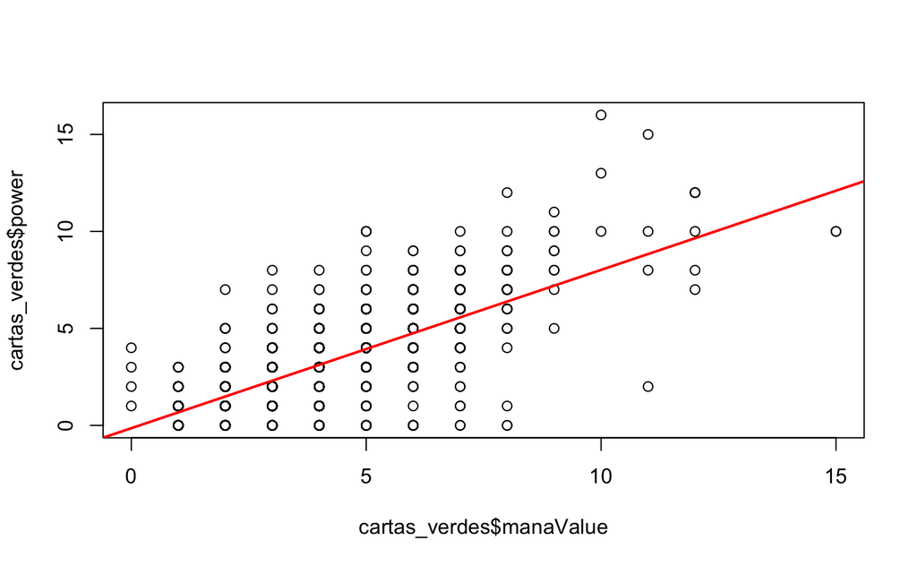

```r
abline(coef(modelo_linear_ataque), lwd = 2, col="red")
```

```r
modelo_linear_defesa <- lm(toughness ~ manaValue, data = cartas_verdes)
summary(modelo_linear_defesa)
```

```
Call:
lm(formula = toughness ~ manaValue, data = cartas_verdes)

Residuals:
    Min      1Q  Median      3Q     Max
-6.3609 -0.7036 -0.0323  0.7440  9.7440

Coefficients:
            Estimate Std. Error t value Pr(>|t|)
(Intercept)  0.15112    0.05756   2.625   0.0087 **
manaValue    0.77623    0.01415  54.862   <2e-16 ***
---
Signif. codes:  0 ‘***’ 0.001 ‘**’ 0.01 ‘*’ 0.05 ‘.’ 0.1 ‘ ’ 1

Residual standard error: 1.293 on 2572 degrees of freedom
Multiple R-squared:  0.5392,    Adjusted R-squared:  0.539
F-statistic:  3010 on 1 and 2572 DF,  p-value: < 2.2e-16
```

Tentaremos prever um valor de ataque com base no custo de invocação para as cartas verdes.

```r
custo_mana <- 5
previsao <- predict(modelo_linear_ataque, newdata = data.frame(manaValue = custo_mana))
print(previsao)
```

```
      1
3.93609
```

# Um mapa de calor que relaciona o custo de mana com a cor da carta, para cada carta unica

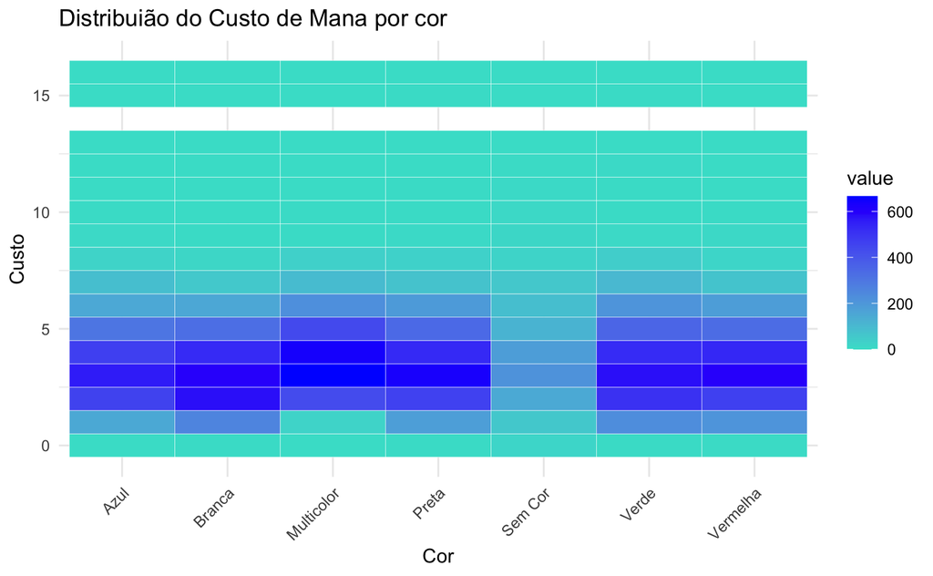

```r
library(ggplot2)
library(reshape2)

cartas_com_mana <- subset(cartas_unicas, !is.na(manaValue) & manaValue != "")
mana_por_cor <- table(cartas_com_mana$colors, cartas_com_mana$manaValue)

mana_melted <- melt(mana_por_cor)

ggplot(mana_melted, aes(Var1, Var2, fill = value)) +
  geom_tile(color = "white") +
  scale_fill_gradient(low = "turquoise", high = "blue") +
  theme_minimal() +
  labs(title = "Distribuião do Custo de Mana por cor", x = "Cor", y = "Custo") +
  theme(axis.text.x = element_text(angle = 45, hjust = 1))
```

# Um mapa de calor que relaciona os pontos de ataque com a cor da carta, para cada carta unica

```r
cartas_com_ataque <- subset(cartas_unicas, !is.na(power) & power != "" & power < 90)
ataque_por_color <- table(cartas_com_ataque$colors, cartas_com_ataque$power)

ataque_melted <- melt(ataque_por_color)

print(ataque_melted)
```

| Var1 | Var2 | value |
| --- | --- | --- |
| Azul | 0 | 151 |
| Branca | 0 | 95 |
| Multicolor | 0 | 70 |
| Preta | 0 | 72 |
| Sem Cor | 0 | 99 |
| Verde | 0 | 154 |
| Vermelha | 0 | 88 |
| Azul | 1 | 606 |
| Branca | 1 | 612 |
| Multicolor | 1 | 259 |

[output cut: 109 more lines]

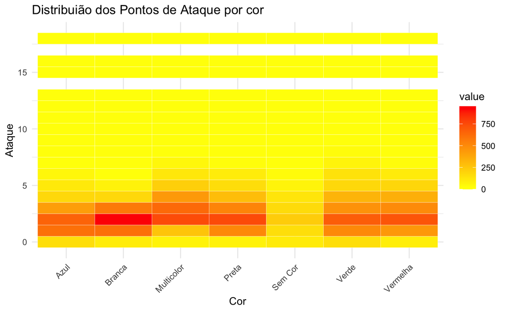

```r
ggplot(ataque_melted, aes(Var1, Var2, fill = value)) +
  geom_tile(color = "white") +
  scale_fill_gradient(low = "yellow", high = "red") +
  theme_minimal() +
  labs(title = "Distribuião dos Pontos de Ataque por cor", x = "Cor", y = "Ataque") +
  theme(axis.text.x = element_text(angle = 45, hjust = 1))
```

Outra previsão, onde usamos diferentes variáveis para predizer quantidade de mana.

```r
library(fmsb)
library(dplyr)

normalizar_atributos <- function(x) {
    return((x - min(x)) / (max(x) - min(x)) * 10)
}
normalizar_media <- function(x) {
  return(((x - min(x, na.rm = TRUE)) / (max(x, na.rm = TRUE) - min(x, na.rm = TRUE)) * 10) + 1 )
}

cartas_unicas_cores_unicas <- filter(
  cartas_unicas,
  colors != "Sem Cor" & colors != "Multicolor"
)

cartas_unicas_cores_unicas$power_norm <- normalizar_atributos(cartas_unicas_cores_unicas$power)
cartas_unicas_cores_unicas$toughness_norm <- normalizar_atributos(cartas_unicas_cores_unicas$toughness)
cartas_unicas_cores_unicas$manaValue_norm <- normalizar_atributos(cartas_unicas_cores_unicas$manaValue)

cartas_unicas_cores_unicas$power_norm <- ifelse(cartas_unicas_cores_unicas$power_norm > 90, NA, cartas_unicas_cores_unicas$power_norm)
cartas_unicas_cores_unicas$toughness_norm <- ifelse(cartas_unicas_cores_unicas$toughness_norm > 90, NA, cartas_unicas_cores_unicas$toughness_norm)
cartas_unicas_cores_unicas$manaValue_norm <- ifelse(cartas_unicas_cores_unicas$manaValue_norm > 90, NA, cartas_unicas_cores_unicas$manaValue_norm)

media_valores_por_cor <- summarise(
  group_by(cartas_unicas_cores_unicas, colors),
  força = mean(power_norm, na.rm = TRUE),
  vida = mean(toughness_norm, na.rm = TRUE),
  custo = mean(manaValue_norm, na.rm = TRUE)
)

print(media_valores_por_cor)
```

| colors | força | vida | custo |
| --- | --- | --- | --- |
| Azul | 0.2311867 | 0.2828100 | 2.402470 |
| Branca | 0.2211683 | 0.2653376 | 2.224612 |
| Preta | 0.2707203 | 0.2663930 | 2.402285 |
| Verde | 0.2860776 | 0.3012644 | 2.431753 |
| Vermelha | 0.2755162 | 0.2604251 | 2.357408 |

```r
media_valores_por_cor$força <- normalizar_media(media_valores_por_cor$força)
media_valores_por_cor$vida <- normalizar_media(media_valores_por_cor$vida)
media_valores_por_cor$custo <- normalizar_media(media_valores_por_cor$custo)

dados_para_grafico_radar <- rbind(
  rep(10, ncol(media_valores_por_cor) - 1),
  rep(0, ncol(media_valores_por_cor) - 1),
  media_valores_por_cor[,-1]
)

print(dados_para_grafico_radar)
```

| força | vida | custo |
| --- | --- | --- |
| 10.000000 | 10.000000 | 10.000000 |
| 0.000000 | 0.000000 | 0.000000 |
| 2.543450 | 6.481219 | 9.586321 |
| 1.000000 | 2.202870 | 1.000000 |
| 8.634036 | 2.461311 | 9.577368 |
| 11.000000 | 11.000000 | 11.000000 |
| 9.372905 | 1.000000 | 7.410899 |

```r
dados_para_grafico_radar[1, ] <- dados_para_grafico_radar[1, ] + 1
dados_para_grafico_radar[2, ] <- dados_para_grafico_radar[2, ] + 1

radarchart(
  dados_para_grafico_radar,
  axistype = 1,
  pcol = c("cyan", "grey", "black", "green", "red"),
  plwd = 2,
  cglcol = "grey",
  cglty = 1,
  axislabcol = "grey",
  caxislabels = seq(0, 14, 2),
  cglwd = 0.8,
  vlcex = 0.8
)

title(main = "Média de atributos por cor")
```

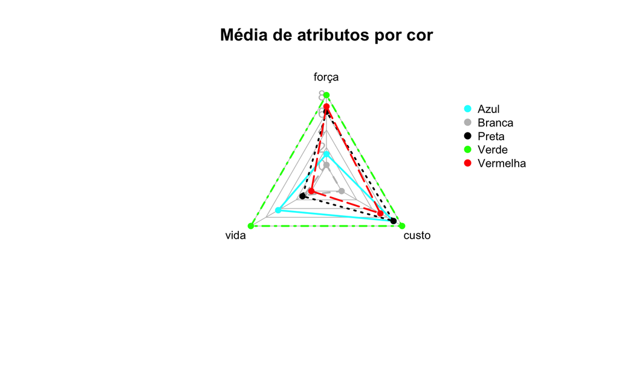

```r
legend(
  x = 1.5, y = 1, legend = media_valores_por_cor$colors, bty = "n",
  pch = 20, col = c("cyan", "grey", "black", "green", "red"),
  text.col = "black", cex = 0.8, pt.cex = 1.5
)
```

```r
modelo_linear_ataque_vida <- lm(manaValue ~ power+toughness+rarity+subtypes, cartas_verdes)

previsao <- predict(modelo_linear_ataque_vida, data.frame(power = 1, toughness = 1, rarity="common", subtypes=c("Human, Soldier")))

print(previsao)
```

```
       1
1.796572
```